# AEEM 3062

# HOMEWORK # 7

# 2022-2023 SPRING

### Name: Slade Brooks

### M#: 13801712

### DUE: 11.59 PM on 2/25/2023

## Problem 1

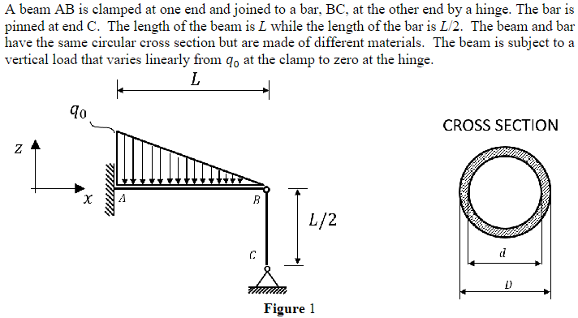

### Part A

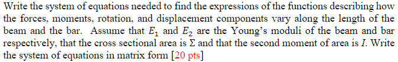

first create diagrams for each section and the corner

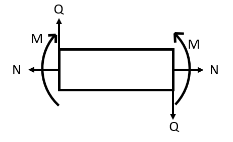

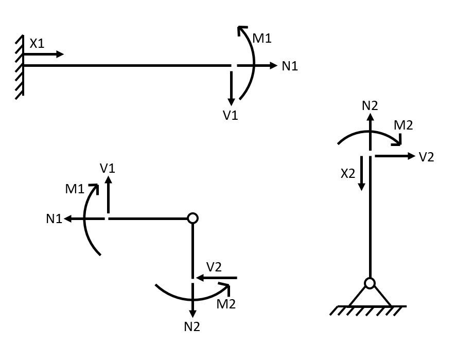

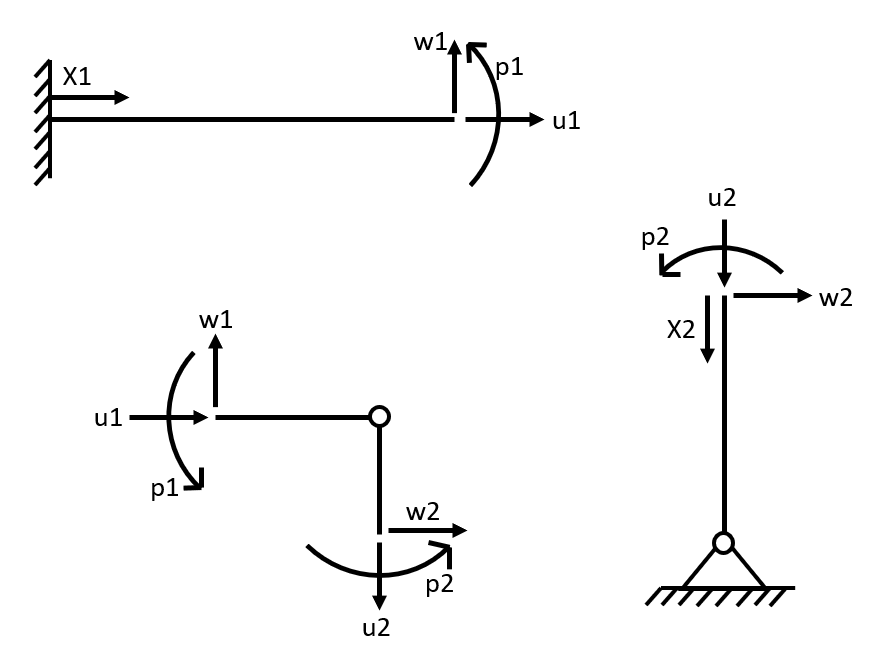

create differential equations for each section

Section 1: $$ \frac{\delta N_1}{\delta x_1} = 0, \ N_1 = C_1 \\ \frac{\delta V_1}{\delta x_1} = -(-\frac{q_o}{L}x + q_o), \ V_1 = \frac{q_o}{2L}x^2 - q_ox + C_2 \\ \frac{\delta M_1}{\delta x_1} = V_1, \ M_1 = \frac{q_o}{6L}x^3 - \frac{q_o}{2}x^2 + C_2x + C_3L \\ \frac{\delta u_1}{\delta x_1} = \frac{N_1}{E_1 \Sigma} = \frac{C_1}{E_1 \Sigma}, \ u_1 = \frac{C_1}{E_1 \Sigma}x + C_4 \\ \frac{\delta \varphi_1}{\delta x_1} = \frac{M_1}{E_1 I}, \ \varphi_1 = \frac{1}{E_1 I}(\frac{q_o}{24L}x^4-\frac{q_o}{6}x^3+\frac{C_2}{2}x^2+C_3Lx+C_5L^2) \\ \frac{\delta w_1}{\delta x_1} = \varphi_1, \ w_1 = \frac{1}{E_1 I}(\frac{q_o}{120L}x^5-\frac{q_o}{24}x^4+\frac{C_2}{6}x^3+\frac{C_3L}{2}x^2+C_5L^3x+C_6L^3) $$

Section 2: $$ \frac{\delta N_2}{\delta x_2} = 0, \ N_2 = C_7 \\ \frac{\delta V_2}{\delta x_2} = 0, \ V_2 = C_8 \\ \frac{\delta M_2}{\delta x_2} = V_2, \ M_2 = C_8x+\frac{C_9L}{2} \\ \frac{\delta u_2}{\delta x_2} = \frac{N_2}{E_2 \Sigma}, \ u_2 = \frac{C_7}{E_2 \Sigma}x + C_{10} \\ \frac{\delta \varphi_2}{\delta x_2} = \frac{M_2}{E_2 I}, \ \varphi_2 = \frac{1}{E_2 I}(\frac{C_8}{2}x^2 + \frac{C_9L}{2}x + C_{11}L^2) \\ \frac{\delta w_2}{\delta x_2} = \varphi_2, \ w_2 = \frac{1}{E_2 I}(\frac{C_8}{6}x^3 + \frac{C_9L}{4}x^2 + C_{11}L^2x + C_{12}L^3) $$

Next we need to define the boundary conditions.

External Boundaries: $$ u_1(0) = 0 \\ w_1(0) = 0 \\ \varphi_1(0) = 0 \\ u_2(L/2) = 0 \\ w_2(L/2) = 0 \\ M_2(L/2) = 0 $$

Corner: $$ w_1(L) = -u_2(0) \\ u_1(L) = w_2(0) \\ N_1(L) + V_2(0) = 0 \\ V_1(L) = N_2(0) \\ M_1(L) = 0 \\ M_2(0) = 0 \\ $$

Then we can apply the boundary conditions to the equations: $$ u_1(0) = 0 = C_4 \\ w_1(0) = 0 = \frac{C_6L^3}{E_1I} \\ \varphi_1(0) = 0 = \frac{C_5L^2}{E_1I} \\ u_2(L/2) = 0 = \frac{C_2L}{2E_2I} + C_{10} \\ w_2(L/2) = 0 = \frac{1}{E_2I}(\frac{L^3}{48}C_8+\frac{L^3}{16}C_9+\frac{L^3}{2}C_{11}+L^3C_{12}), \ \frac{1}{48}C_8+\frac{1}{16}C_9+\frac{1}{2}C_{11}+C_{12} = 0 \\ M_2(L/2) = 0 = \frac{L}{2}(C_8+C_9), \ C_8+C_9=0 \\ w_1(L)+u_2(0) = 0 = C_{10} + \frac{1}{E_1 I}(\frac{q_o}{120}L^4-\frac{q_o}{24}L^4+\frac{C_2}{6}L^3+\frac{C_3}{2}L^3+C_5L^3x+C_6L^3), \\ C_{10} + \frac{L^3}{E_1I}(\frac{C_2}{6} + \frac{C_3}{2} + C_5 + C_6) = \frac{L^4q_o}{30E_1I} \\ u_1(L) - w_2(0) = \frac{LC_1}{E_1 \Sigma} + C_4 - \frac{L^3C_{12}}{E_2I} \\ N_1(L) + V_2(0) = 0 = C_1 + C_8 \\ V_1(L) - N_2(0) = 0 = \frac{q_0L}{2} - q_oL + C_2 - C_7, \ C_2 - C_7 = \frac{q_0L}{2} \\ M_1(L) = 0 = \frac{L^2q_o}{6} - \frac{L^2q_o}{2} + L(C_2+C_3), \ C_2+C_3 = \frac{Lq_o}{3} \\ M_2(0) = 0 = \frac{LC_9}{2} $$

Lastly we can create a matrix from the equations:

$$ \fbox{$ \begin{bmatrix} 0 & 0 & 0 & 1 & 0 & 0 & 0 & 0 & 0 & 0 & 0 & 0 \\ 0 & 0 & 0 & 0 & 0 & \frac{L^3}{E_1I} & 0 & 0 & 0 & 0 & 0 & 0 \\ 0 & 0 & 0 & 0 & \frac{L^2}{E_1I} & 0 & 0 & 0 & 0 & 0 & 0 & 0 \\ 0 & 0 & 0 & 0 & 0 & 0 & \frac{L}{2E_2I} & 0 & 0 & 1 & 0 & 0 \\ 0 & 0 & 0 & 0 & 0 & 0 & 0 & \frac{1}{48} & \frac{1}{16} & 0 & \frac{1}{2} & 1 \\ 0 & 0 & 0 & 0 & 0 & 0 & 0 & 1 & 1 & 0 & 0 & 0 \\ 0 & \frac{L^3}{6E_1I} & \frac{L^3}{2E_1I} & 0 & \frac{L^3}{E_1I} & \frac{L^3}{E_1I} & 0 & 0 & 0 & 1 & 0 & 0 \\ \frac{L}{E_1 \Sigma} & 0 & 0 & 1 & 0 & 0 & 0 & 0 & 0 & 0 & 0 & -\frac{L^3}{E_2I} \\ 1 & 0 & 0 & 0 & 0 & 0 & 0 & 1 & 0 & 0 & 0 & 0 \\ 0 & 1 & 0 & 0 & 0 & 0 & -1 & 0 & 0 & 0 & 0 & 0 \\ 0 & 1 & 1 & 0 & 0 & 0 & 0 & 0 & 0 & 0 & 0 & 0 \\ 0 & 0 & 0 & 0 & 0 & 0 & 0 & 0 & \frac{L}{2} & 0 & 0 & 0 \end{bmatrix} \begin{bmatrix} C_1 \\ C_2 \\ C_3 \\ C_4 \\ C_5 \\ C_6 \\ C_7 \\ C_8 \\ C_9 \\ C_{10} \\ C_{11} \\ C_{12} \end{bmatrix} = \begin{bmatrix} 0 \\ 0 \\ 0 \\ 0 \\ 0 \\ 0 \\ \frac{L^4q_o}{30E_1I} \\ 0 \\ 0 \\ \frac{q_oL}{2} \\ \frac{q_oL}{3} \\ 0 \end{bmatrix} $} $$

### Part B

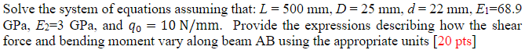

We can convert all values to meters and Pa, then plug in to the matrix above and solve for the constants. I created the matrix in matlab with variables for each value and used matlab to solve.

$$ C_1 = 0 \\ C_2 = 2496.4 \\ C_3 = -829.73 \\ C_4 = 0 \\ C_5 = 0 \\ C_6 = 3.583E-14 \\ C_7 = -3.6023 \\ C_8 = 0 \\ C_9 = 0 \\ C_{10} = 0.03911 \\ C_{11} = 0 \\ C_{12} = 0 \\ $$

Moment: $$ M_1(x) = \frac{q_o}{6L}x^3 - \frac{q_o}{2}x^2 + C_2x +C_3L = \frac{(10000\text{N/m})}{6(0.5\text{m})}x^3 - \frac{(10000\text{N/m})}{2}x^2 + (2496.4\text{N})x - (829.73\text{N})(0.5\text{m}) \\ \fbox{$M_1(x) = (3333.3\text{N/m$^2$})x^3 - (5000\text{N/m})x^2 + (2496.4\text{N})x - 414.864\text{Nm}$} $$

Since x is in meters, the units for bending moment are Newton-meters.

### Part C

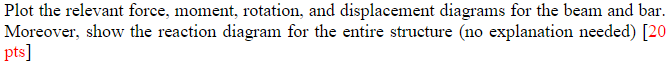

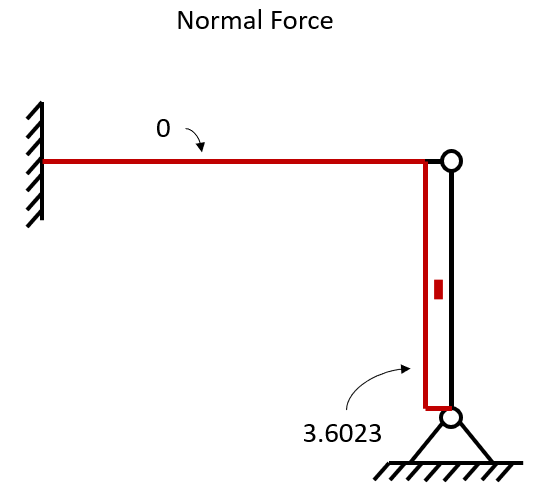

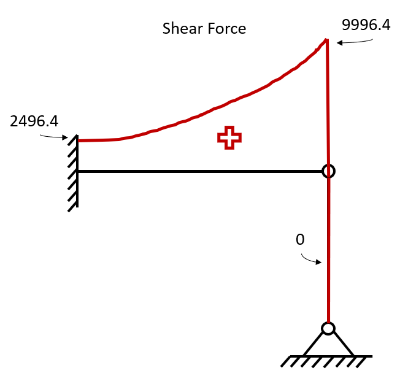

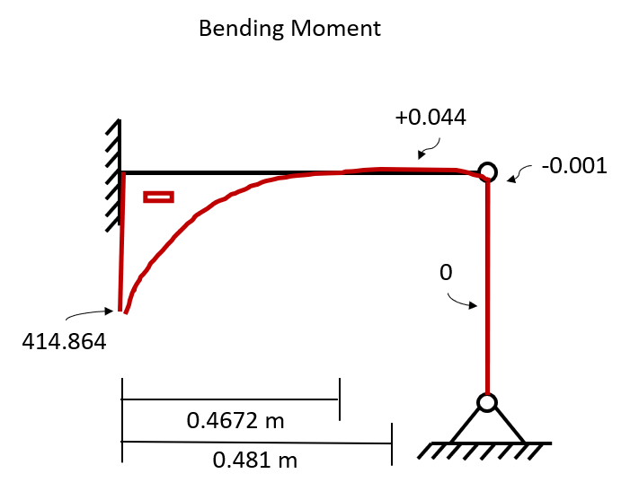

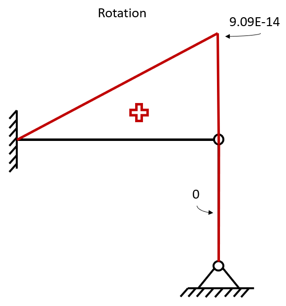

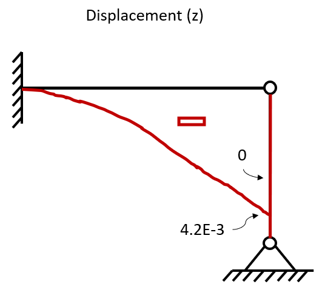

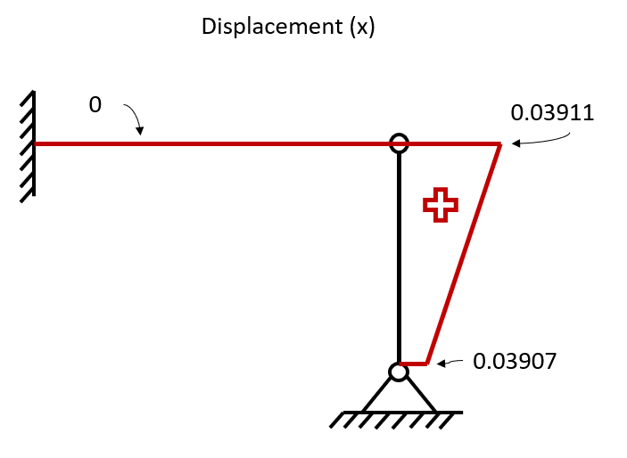

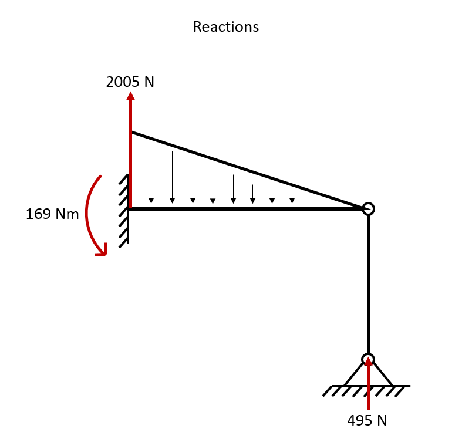

### Part D

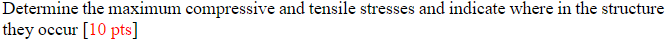

The max compressive stress will be throughout x2 (since N2 is constant along it). There is no tensile because there is no positive N in either bar.

$$ \sigma_{max} = \frac{3.6023}{A_2} = \frac{3.6023}{\pi(D^2 - d^2)} = \fbox{$8132.25 \text{N/m} = \sigma_{max}$} $$

## Problem 2

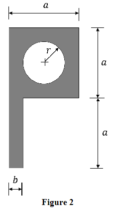

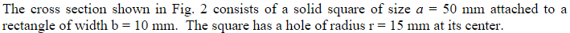

### Part A

To find the centroid we will split the cross section into 2 shapes. One will be a 50x10 rectangle and the other will be a 50x50 square with a 15 radius hole in the center.

First find the centroid and area of each component individually.

#### Rectangle

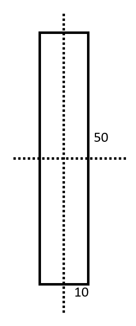

The centroid of the rectangle will be at the intersection of its two axes of symmetry, which is the midpoint of both edges.

Its centroid is at $(5, 25)$ and its area is $50*10 = 500 mm^2$.

#### Square

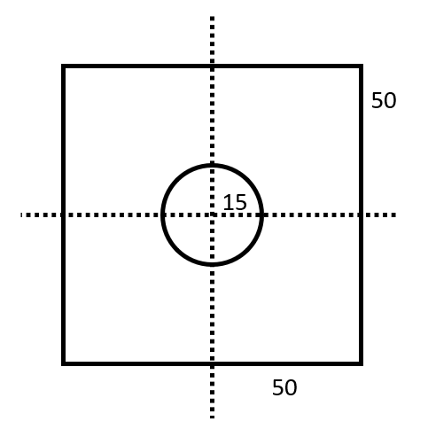

The centroid of the square will be at the intersection of its two axes of symmetry, which is the midpoint of both edges.

Since we defined the origin at the bottom left corner of the rectangle, the centroid of the square is $(25, 25 + 50) = (25, 75)$ and its area is $50*50 - \pi*(15)^2 = 1793.14165 mm^2$.

#### Combined

The combined centroid is defined as the sum of each component's centroid times its area divided by the total area of the shape.

For y direction: $$ y_C = \frac{5*500 + 25*1793.14165}{500 + 1793.14165} = 20.64 mm $$

For z direction: $$ z_C = \frac{25*500 + 75*1793.14165}{500 + 1793.14165} = 64.1 mm $$

Therefore the centroid of the cross section is $(20.64, 64.1)$ mm.

### Part B

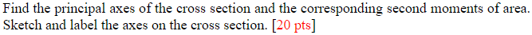

First we will find the moment of intertia about each axis of each component.

Square: $$ I_{sz} = \frac{a^4}{12} - \frac{\pi r^2}{4} \\ I_{sy} = \frac{a^4}{12} - \frac{\pi r^2}{4} $$

Rectangle: $$ I_{rz} = \frac{ab^3}{12} \\ I_{ry} = \frac{a^3b}{12} $$

We will define $y_s$, $y_r$, $z_s$, and $z_r$ as the distances between the centroid of the total shape and the individual centroids of each component. These will be used in the parallel axis theorem in the next step.

Square: $$ z = A_s z_s^2 \\ y = A_s y_s^2 $$

Rectangle: $$ z = A_r z_r^2 \\ y = A_r y_r^2 $$

Then we can define the arbitrary axis moments of inertia (about the centroid). $I_\eta$ is the sum of the moments of intertia in the z direction corrected with the parallel axis them (and $I_\zeta$ is the same but in the y direction).

$$ I_\eta = \frac{a^4}{12} - \frac{\pi r^4}{4} + A_s z_s^2 + \frac{ab^3}{12} + A_r z_r^2 \\ I_\zeta = \frac{a^4}{12} - \frac{\pi r^4}{4} + A_s y_s^2 + \frac{a^3b}{12} + A_r y_r^2 \\ I_{\eta \zeta} = A_s z_s y_s + A_r z_r y_r $$

Then we can evaluate these with the given values:

$$ I_\eta = \frac{50^4}{12} - \frac{\pi (15)^2}{4} + (1793.14165)(64.1 - 75)^2 +\frac{50*10^3}{12} + (500)(64.1 - 25)^2 = 1.5E6 \text{mm$^4$} $$

$$ I_\zeta = \frac{50^4}{12} - \frac{\pi (15)^2}{4} + (1793.14165)(20.64 - 25)^2 +\frac{50^3*10}{12} + (500)(20.64 - 5)^2 = 7.8E5 \text{mm$^4$} $$

$$ I_{\eta \zeta} = (1793.14165)(64.1-75)(20.64-25) + (500)(64.1-25)(20.64-5) = 3.91E5\text{mm$^4$} $$

Now we can determine the rotation of the principle axes through the centroid using the equation: $$ 2\theta' = \tan^{-1}{(\frac{2I_{\eta \zeta}}{I_\zeta - I_\eta})} $$

$$ \theta' = \frac{1}{2}\tan^{-1}{\frac{2(3.91E5)}{7.8E5-1.5E6}} $$

$$ \theta' = -23.7^\circ $$

Then we can determine the second moments of area: $$ \begin{matrix} I_y \\ I_z \end{matrix} = \frac{I_\eta + I_\zeta}{2} \pm \sqrt{(\frac{I_\eta + I_\zeta}{2})^2 + I_{\eta \zeta}^2} \\ $$

We can substitute in the values we calculated: $$ \begin{matrix} I_y \\ I_z \end{matrix} = \frac{1.5E6+7.8E5}{2} \pm \sqrt{(\frac{1.5E6+7.8E5}{2})^2 + (3.91E5)^2} $$

$$ \fbox{$ I_y = 2.345E6 \text{mm$^4$}$} \\ \fbox{$I_z = -6.52E4 \text{mm$^4$} $} $$

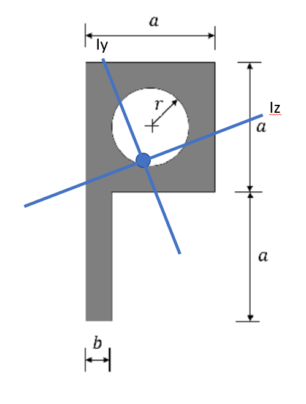